# Word embeddings

class notes

# Introduction

As we have been mentioning, textual information, unlike other data, is a type of unstructured information. This makes it necessary that, in order to work with text, we must give it some kind of structure.

One of the basic ways to structure a corpus of raw text is through the Bag of Words model (BoW). For this, we construct a Term-Frequency Matrix (TFM). Each row is a document from the corpus and each column is a term from the vocabulary. At the intersection of rows and columns, we can have different forms of counting: the raw frequency of that term in each document, normalized frequency, TF-IDF frequency, etc. Each document is now represented as a vector over the vocabulary, and vice versa, each term of the vocabulary as a vector over the documents of the corpus.

This is one of the possible ways to structure raw text, that is, to vectorize raw text. However, this representation presents some problems:

- it does not maintain the order of language, the structure and sequential order of words and n-grams are lost
- it suffers from high dimensionality (the number of columns is the number of unique words in the vocabulary ~10,000) and
- since a specific text only uses a subset of words, most cells in TFM are zero; this is called sparsity
- in computational terms, as the corpus size and sparsity increases, RAM required to hold the corpus in memory increases in a non-linear form.

# Word embeddings

The central idea of word embeddings can be summarized in John Firth’s quote: “you shall know a word by the company it keeps”. The hypothesis behind word embeddings is that, in some way, word contexts are strongly correlated with their meaning. Words that appear “close” probably have similar meanings.

Thus, the different word embedding techniques seek to represent textual data in a vectorial form; this representation aims to be smaller than that of a TFM, generally between 100 and 300 dimensions. That is, it is expected to represent each word, term of the vocabulary as a vector of length between 100 and 300.

An important point to note is that word embeddings are learned from a corpus (usually large) of text. Particularly, from the analysis of word contexts, word embeddings seek to capture the semantics of such words.

We could represent the problem that word embedding models seek to solve following (Kozlowski, Taddy, and Evans 2019):

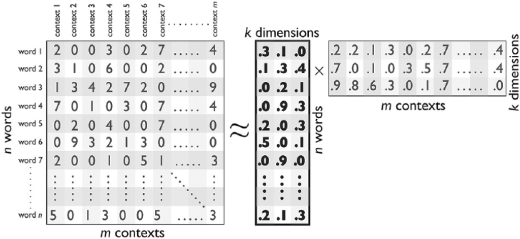

**Source:** (Kozlowski, Taddy, and Evans 2019)

The question is how to represent all the words of a corpus in a $k$-dimensional space that also preserves the distances between the $n$ words across the $m$ contexts. The output of a word embedding model is a matrix of $n \times k$. Thus, it is assumed that in a word embedding, words that share similar contexts can be represented close in the k-dimensional space; whereas words that do not share contexts will be located far apart in that space. The metric generally used to measure the distances (or rather, the inverse of the distances) between words in the embedding space is the cosine similarity, defined as the cosine of the angle between two vectors; that is, the dot product of the vectors divided by the product of their lengths:

One of the differences between the many techniques for training a word embedding will be how they define those “contexts” and how they operate with them.

$$cos(A,B) = \frac{A \times B}{||A|| \times ||B||}$$

This metric varies between -1 and 1, where -1 means that the two vectors are opposite, +1 that the vectors are proportional, and 0 that the vectors are orthogonal.

**How to obtain word embeddings** To work with word embedding models, there are two basic approaches.

We can **train an embedding from scratch** based on a specific task: for example, if we were looking to train a classification model for literary works, we could generate a vector representation of the vocabulary from the corpus. Then, we could use that representation as input to construct features for the classification model. The advantage of this approach is that the embedding is likely to be a highly efficient representation of our corpus. The disadvantage is that large corpora are required to obtain good representations from word embeddings. For example, in (Pennington, Socher, and Manning 2014), the original paper of [GloVe](https://nlp.stanford.edu/projects/glove/), one of the most commonly used embedding models, different trial models were trained on the following corpora:

- 2010 Wikipedia dump: 1 billion tokens
- 2014 Wikipedia dump: 1.6 billion tokens
- Gigaword 5: 4.3 billion tokens

Then, they combine Gigaword 5 and Wikipedia 2014. This often entails relatively long training times.

However, since many times we don’t have a corpus large enough to undertake the estimation of a vector representation based on embeddings, a very common option is to **use a pre-trained model**. Additionally, this approach allows for the application of some principles of transfer learning, meaning the idea that it’s possible to apply a learned model to solve a similar or related task without having to train another model from scratch. If the corpus on which a word embedding is trained is large and representative enough of a language, we can consider that model as a first general model of the language, or at least of the semantics of that language. If this is true, then the embedding managed to capture certain aspects of the word meanings that are general and not restricted to a specific corpus. Thus, we can use a pre-trained embedding and apply it to a specific task, for example, the one mentioned in the previous paragraph. We’ll use the embedding as input to generate the features of our classification model. But the difference is that we don’t train the embedding ourselves but rather use one that is already pre-trained.

In a way, word embeddings were a first milestone in the paradigm shift in NLP that we are currently experiencing. Indeed, with the advent of Large Language Models (LLMs), we stopped thinking about training a model for every task and every corpus we want to solve. Currently, it’s more common, for example, specific tasks such as hate speech detection (Pérez et al. 2023), to use some pre-trained model and perform a fine-tuning process to solve the task at hand.

Fine-tuning means taking the parameters of a pre-trained model and modifying only some of its parameters to adapt it to a new domain.

## Assumptions of word embeddings

Let’s try to systematize some very general assumptions of this type of models. In general, one of their most interesting features is that they allow for the relaxation of many of the assumptions of BoW. For example, since an embedding is trained based on its context, the assumption of independence between words is greatly attenuated.

Moreover, the use of context allows for interaction between words, so a lower dimensionality than that in BoW is expected.

It introduces a metric of similarity ( *cosine similarity*) that corresponds to semantics: semantically similar words will be close in space and therefore will have a high similarity; conversely, words with very different meanings will be far apart in space and thus will show low values in the similarity metric. In fact, it’s expected that synonyms will be *very* close.

The following figure illustrates this idea:

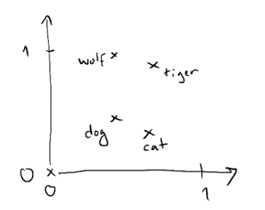

**Source:** (Chollet and Allaire 2017)

There are four words embedded in this model of $k=2$ (two dimensions): “cat”, “dog”, “wolf”, and “tiger”. We can think of the semantic relationships between these words as geometric transformations and vector operations in this $k=2$ space. The same vector allows us to move from “cat” to “tiger” and from “dog” to “wolf”. In that sense, we could try to interpret that vector as a dimension that tells us about the “wild” or “domestic” nature of an animal.

To conclude this general approach, [let’s see a slightly more realistic example](http://jalammar.github.io/illustrated-word2vec/):

Let’s imagine we have the following vector representing the word “king”. It’s a strip of 50 numbers.

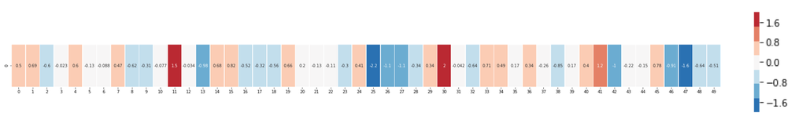

**Source:** http://jalammar.github.io/illustrated-word2vec/

On its own, it’s not very useful, so we can contrast it with other words in the embedding.

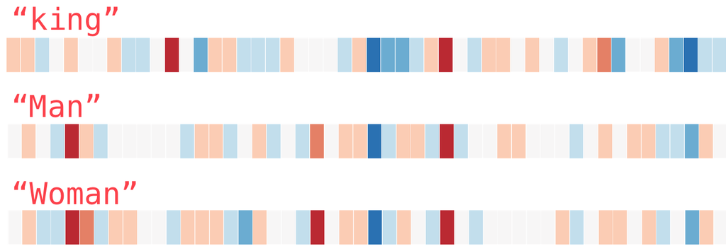

**Source:** http://jalammar.github.io/illustrated-word2vec/

Intuitively, from the color-coded chart, we can see that the vectors for “man” and “woman” appear to be more similar to each other.

Let’s extend the list of words in the embedding a bit:

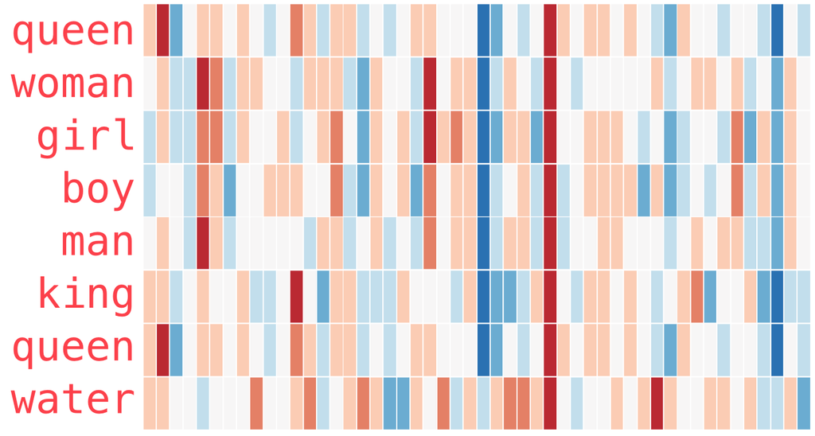

**Source:** http://jalammar.github.io/illustrated-word2vec/

“Woman” and “girl” are similar to each other in several places in the vector; the same goes for “man” and “boy”.

Furthermore, “boy” and “girl” also show some similarities in certain elements of the vector, which are different from “man” or “woman”. The question here is whether these elements of the vector manage to somehow encode a sense of “youth”.

The last word (“water”) is the only one representing an object and not a person: it can be seen that the vector for this word is quite contrasting to the rest of the words in the figure.

There are several places where “king” and “queen” resemble each other and differ from all the others. What could they be representing?

Now, earlier we talked about the possibility of word embeddings encoding some semantic dimensions. Let’s see the following example (quite classic) based on an analogy: what is to “woman” what “king” is to “man”? This is a typical analogy question: the answer is clear from semantics: “queen”.

The interesting thing is that we can pose this type of analogy problem based on vector operations in a word embedding: indeed, we can take the vector “king”, subtract the vector “man” from it, and add the vector “woman” to it. That gives us an “artificial” vector.

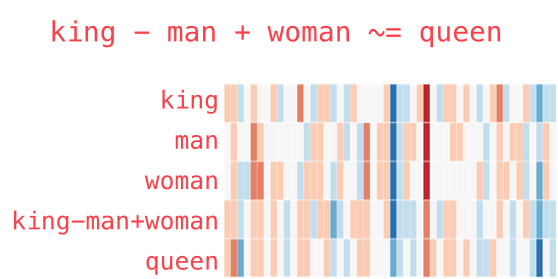

**Source:** http://jalammar.github.io/illustrated-word2vec/

Then, we can search among all the vectors in the embedding which one is the closest (using cosine similarity metric) to this generated vector. Indeed, it seems like magic, but the one that is closest is the vector for “queen”. (If you don’t believe us, you can try these kinds of operations in the guided practice.)

These types of analogy tasks are often used to evaluate the performance of word embeddings. There is a series of relatively common questions used to calculate the accuracy of each embedding model. Thus, for example, questions like “What is to Greece what Paris is to France?” are used to compare the embedding’s “response” to the real response. (Mikolov, Chen, et al. 2013) used about 8,869 semantic questions and about 10,675 syntactic questions.

# Popular word embeddings techniques

So far, we’ve spoken in very general terms about word embedding models. While we won’t delve into the specific technical details of each model (for that, you can refer to each model’s references), we will give a general overview of each one’s general characteristics.

## Word2vec

This is the “granpa” of all embeddings models. It was developed by Google in 2013(Mikolov, Chen, et al. 2013) (Mikolov, Sutskever, et al. 2013). How does word2vec works?

**Tokenization:** The text is tokenized, meaning it’s split into individual words or tokens. Punctuation and other non-essential characters are usually removed.

**Building Vocabulary:** Word2Vec constructs a vocabulary from the corpus, which is essentially a list of unique words in the corpus.

**One-hot Encoding:** Each word in the vocabulary is represented as a one-hot encoded vector. This means that each word is represented as a vector where all elements are zero except for one element which represents the index of that word in the vocabulary.

**Neural Network Architecture:** Word2Vec uses a shallow neural network with either a continuous bag of words (CBOW) or skip-gram architecture. In CBOW, the model predicts the target word based on the context words within a window around the target word. In skip-gram, the model predicts context words given a target word.

**Training:** The Word2Vec model is trained using the neural network on the corpus. During training, the model adjusts its internal weights such that the predicted context (or target) words become more accurate.

**Word Embeddings:** Once the model is trained, the weights of the hidden layer (between the input and output layers) are used as word embeddings. These embeddings capture semantic relationships between words. Words with similar meanings or that appear in similar contexts will have similar vector representations.

## GloVe

GloVe(Pennington, Socher, and Manning 2014) differs from Word2Vec in its approach to learning word embeddings, but it serves a similar purpose: capturing semantic relationships between words in a vector space.

Here’s how GloVe works:

**Co-occurrence Matrix:** GloVe starts by constructing a co-occurrence matrix from the corpus. This matrix captures how frequently words co-occur within a context window. The context can be defined based on words within a fixed window size or using other contextual information like sentence boundaries.

**Normalization:** The co-occurrence counts in the matrix are typically normalized to give more weight to less frequent word pairs and reduce the influence of very common pairs.

**Objective Function:** GloVe defines an objective function that aims to learn word vectors such that the dot product of two word vectors equals the logarithm of the probability of their co-occurrence.

**Training:** The objective function is optimized using techniques like gradient descent to learn word vectors that minimize the difference between the predicted and actual co-occurrence counts.

**Word Embeddings:** Once trained, the learned word vectors represent the embeddings for each word in the vocabulary. These embeddings capture semantic relationships between words based on their co-occurrence patterns in the corpus.

## FastText

FastText (Bojanowski et al. 2017) (Joulin et al. 2016) is an extension of the Word2Vec model developed by Facebook AI Research. It shares similarities with Word2Vec but introduces several innovations, particularly in how it represents words and handles out-of-vocabulary words. FastText is known for its ability to generate word embeddings for rare or out-of-vocabulary words, making it particularly useful in tasks where robustness to unseen words is important.

Here’s how FastText functions:

**Subword Representation:** Unlike Word2Vec, which represents each word as a single vector, FastText represents words as a bag of character n-grams (subword units). This allows FastText to capture morphological information and handle out-of-vocabulary words efficiently.

**Building Vocabulary:** FastText constructs a vocabulary from the training corpus, considering both full words and character n-grams as vocabulary items.

**Word Embeddings:** FastText learns embeddings for each word in the vocabulary by considering the embeddings of its constituent character n-grams. The embedding for a word is the sum of the embeddings of its character n-grams.

**Training:** FastText trains the embeddings using the Skip-gram model, similarly to Word2Vec. It predicts context words given a target word, but instead of treating each word as a single entity, it considers subword units.

**Handling Out-of-Vocabulary Words:** Because FastText represents words as a combination of character n-grams, it can generate embeddings for out-of-vocabulary words by summing the embeddings of their constituent character n-grams. This makes FastText more robust to rare and unseen words compared to traditional word embedding models.

**Hierarchical Softmax or Negative Sampling:** FastText can use hierarchical softmax or negative sampling techniques during training to speed up the training process and improve scalability, similar to Word2Vec.

Overall, FastText offers several advantages over traditional word embedding models like Word2Vec, including the ability to handle out-of-vocabulary words, capture morphological information, and improve performance on tasks involving rare words or languages with rich morphology.

The utility of these models from a computer science perspective is clear. Indeed, word embeddings marked a qualitative leap in the evolution of NLP, allowing for the application of transfer learning techniques to this domain, resulting in improvements in many tasks such as automatic translation, text classification, etc.

In social sciences, a classic use of these techniques is linked to the goal of identifying cultural biases and stereotypes. By analyzing a large and representative corpus of a language or a specific society, word embeddings can be used to identify how certain forms of inequality are expressed and reproduced in language.

We’ll see two examples regarding this. The first (Kozlowski, Taddy, and Evans 2019) uses word2vec and other models based on various corpora, to generate word embeddings over the period 1900-2000. They then construct a series of independent dimensions (class, wealth, gender, status, etc.) and compare them with different cultural dimensions. The following figure illustrates what we mean:

They use the Google NGram dataset, containing around a million books, and Google News, which contains a large number of news articles

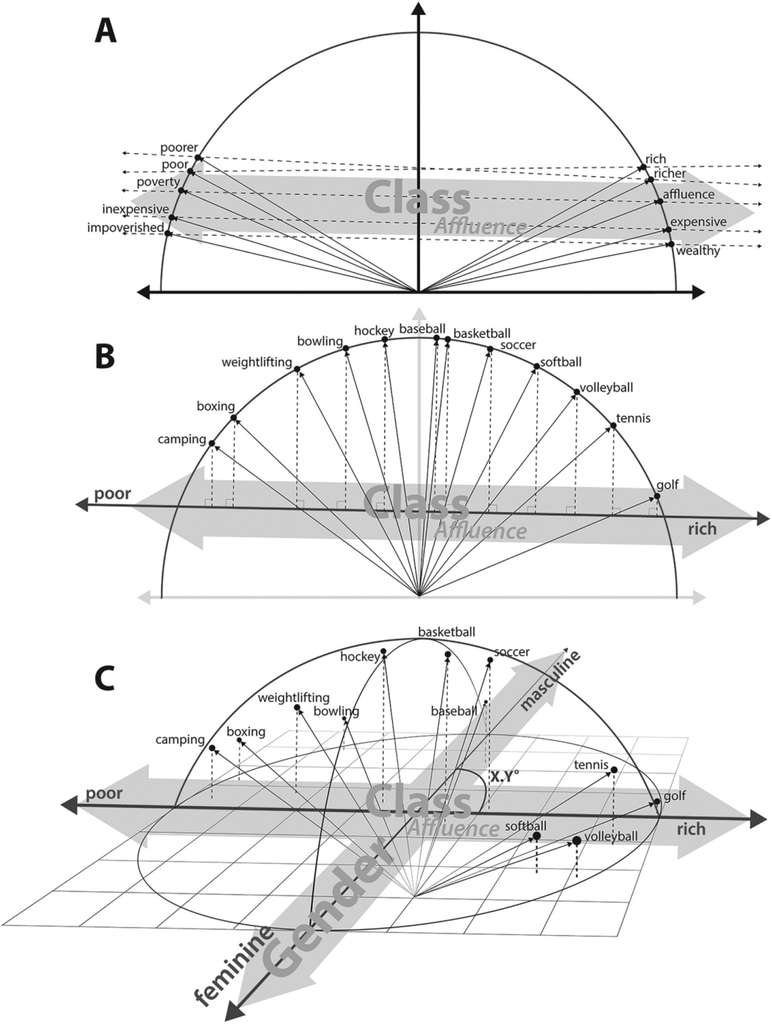

**Source:** (Kozlowski, Taddy, and Evans 2019)

The first panel (A) shows the construction of the “affluence” dimension. It is constructed by calculating the difference between vectors of word pairs: $rich - poor$, $priceless-worthless$, etc. These vectors are then averaged. The result is a vector summarizing the “affluence” dimension.

Next, the cosine similarity is calculated between this “affluence” dimension and different terms related, for example, to cultural goods. This allows them to “project” them onto the “affluence” dimension. Panel B shows the position of different sports. Thus, “camping” and “boxing” appear strongly associated with the poverty pole, while “golf” and “tennis” are associated with the rich pole of the “affluence” dimension.

**Discussion** Panel C shows the position of sports in two dimensions: “affluence” and “gender”. What can you observe in this graph?

They also perform different comparisons with other cultural dimensions over time and several validations with external sources (such as a survey of cultural consumption).

**Discussion** What kind of limitations do you think can be visualized in this methodology?

# Final comments

The use of word embeddings largely paved the way for techniques that are now state-of-the-art in NLP. Thus, transformer models and LLMs use different forms of embeddings in some of their layers. While it exceeds the scope of this class, it’s important to mention that the embeddings we work with here are “static”, meaning there is only one embedding per word.

An innovation of transformer models is related to the possibility they introduced of estimating dynamic embeddings. For example, the sentences “I sat on the bank of the river” and “I deposited money in the bank” use the term “bank” in two different senses (a seat or a financial institution). Since models like word2vec or GloVe or FastText generate the same embedding for both sentences, they would not be able to capture these two different meanings. Contextual embeddings solve this problem by generating different vectors depending on each context in which the word appears. ELMO (Peters et al. 2018) was one of the first models to use this form of contextualized embeddings. This, along with other innovations such as self-attention mechanisms (Vaswani et al. 2023), opened the possibility of training larger and more general language models (LLMs) and tackling NLP tasks more efficiently.

# References

Bojanowski, Piotr, Edouard Grave, Armand Joulin, and Tomas Mikolov. 2017. “Enriching Word Vectors with Subword Information.” https://arxiv.org/abs/1607.04606.

Chollet, François, and J. J. Allaire. 2017. *Deep Learning with r*. USA: Manning Publisher.

Garg, Nikhil, Londa Schiebinger, Dan Jurafsky, and James Zou. 2018. “Word Embeddings Quantify 100 Years of Gender and Ethnic Stereotypes.” *Proceedings of the National Academy of Sciences* 115 (16): E3635–44. https://doi.org/10.1073/pnas.1720347115.

Joulin, Armand, Edouard Grave, Piotr Bojanowski, and Tomas Mikolov. 2016. “Bag of Tricks for Efficient Text Classification.” https://arxiv.org/abs/1607.01759.

Kozlowski, Austin C., Matt Taddy, and James A. Evans. 2019. “The Geometry of Culture: Analyzing the Meanings of Class Through Word Embeddings.” *American Sociological Review* 84 (5): 905–49. https://doi.org/10.1177/0003122419877135.

Mikolov, Tomas, Kai Chen, Greg Corrado, and Jeffrey Dean. 2013. “Efficient Estimation of Word Representations in Vector Space.” https://arxiv.org/abs/1301.3781.

Mikolov, Tomas, Ilya Sutskever, Kai Chen, Greg Corrado, and Jeffrey Dean. 2013. “Distributed Representations of Words and Phrases and Their Compositionality.” https://arxiv.org/abs/1310.4546.

Pennington, Jeffrey, Richard Socher, and Christopher D. Manning. 2014. “GloVe: Global Vectors for Word Representation.” In *Empirical Methods in Natural Language Processing (EMNLP)*, 1532–43. http://www.aclweb.org/anthology/D14-1162.

Pérez, Juan Manuel, Franco M. Luque, Demian Zayat, Martín Kondratzky, Agustín Moro, Pablo Santiago Serrati, Joaquín Zajac, et al. 2023. “Assessing the Impact of Contextual Information in Hate Speech Detection.” *IEEE Access* 11: 30575–90. https://doi.org/10.1109/ACCESS.2023.3258973.

Peters, Matthew E., Mark Neumann, Mohit Iyyer, Matt Gardner, Christopher Clark, Kenton Lee, and Luke Zettlemoyer. 2018. “Deep Contextualized Word Representations.” In *Proceedings of the 2018 Conference of the North American Chapter of the Association for Computational Linguistics: Human Language Technologies, Volume 1 (Long Papers)*, edited by Marilyn Walker, Heng Ji, and Amanda Stent, 2227–37. New Orleans, Louisiana: Association for Computational Linguistics. https://doi.org/10.18653/v1/N18-1202.

Vaswani, Ashish, Noam Shazeer, Niki Parmar, Jakob Uszkoreit, Llion Jones, Aidan N. Gomez, Lukasz Kaiser, and Illia Polosukhin. 2023. “Attention Is All You Need.” https://arxiv.org/abs/1706.03762.